# 图像编码｜教师离线证据

对应85页冻结版。先在PPTX提问、收学生回答，再展开当前证据。其余保持折叠，不提前分发本文件。

图像为已有JPEG的再处理；曲线为数学模型。只计像素码字的B与完整PNG文件长度分开。保存读回检验目标是已量化像素。E1先提交，再回到PPTX81–82页反馈。

**准备｜打开原图，不运行后面的实验**

```
素材就绪；原图尺寸： (886, 1000)
```

**D1｜采样后，每格的颜色怎样记录？（Q3–Q6，6–14页）**

原图同一区域

[figure not shown]

每格的平均RGB

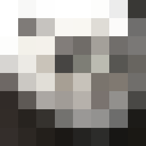

| 编号 | 代表色 | RGB | 码字 |
| --- | --- | --- | --- |
| 0 |  | (36, 33, 27) | — |
| 1 |  | (119, 118, 110) | — |
| 2 |  | (188, 187, 179) | — |
| 3 |  | (242, 240, 230) | — |

**D1证据｜用相同规则处理64个样本**

平均RGB

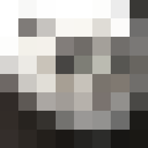

限制为4色

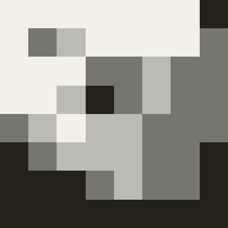

| 样本位置 | 平均RGB（显示近似） | 代表色编号 | 代表色RGB |
| --- | --- | --- | --- |
| 第2行，第3列 | (198.11, 195.15, 190.75) | 2 | (188, 187, 179) |

**D2｜怎样编码？每像素用几bit？（Q5–Q6，11–14页）**

| 颜色 |  |  |  |  |  |  |  |  |
| --- | --- | --- | --- | --- | --- | --- | --- | --- |
| 位置 | 1 | 2 | 3 | 4 | 5 | 6 | 7 | 8 |
| 编号 | 3 | 3 | 2 | 0 | 1 | 2 | 1 | 1 |

**D2证据｜编号换成固定长度码字**

| 颜色 |  |  |  |  |  |  |  |  |
| --- | --- | --- | --- | --- | --- | --- | --- | --- |
| 位置 | 1 | 2 | 3 | 4 | 5 | 6 | 7 | 8 |
| 编号 | 3 | 3 | 2 | 0 | 1 | 2 | 1 | 1 |
| 码字 | 11 | 11 | 10 | 00 | 01 | 10 | 01 | 01 |

```
整图像素数： 64 ；固定码字数： 64
```

**D3｜怎样让数字熊猫更接近原图？（Q7，19–20页）**

8×8，均使用4色

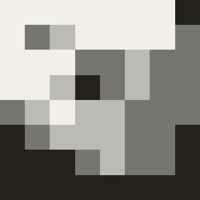

16×16，均使用4色

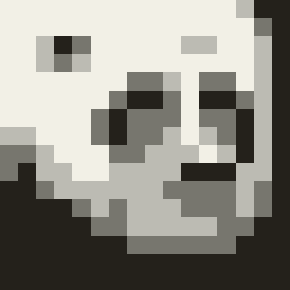

**D3读码｜红框里的8个像素怎样编码？（Q7-read，21–22页）**

| 颜色 |  |  |  |  |  |  |  |  |
| --- | --- | --- | --- | --- | --- | --- | --- | --- |
| 位置 | 1 | 2 | 3 | 4 | 5 | 6 | 7 | 8 |
| 编号 | 3 | 3 | 1 | 0 | 0 | 1 | 3 | 0 |

**D3读码核对｜保留前导0**

| 颜色 |  |  |  |  |  |  |  |  |
| --- | --- | --- | --- | --- | --- | --- | --- | --- |
| 位置 | 1 | 2 | 3 | 4 | 5 | 6 | 7 | 8 |
| 编号 | 3 | 3 | 1 | 0 | 0 | 1 | 3 | 0 |
| 码字 | 11 | 11 | 01 | 00 | 00 | 01 | 11 | 00 |

```
这一段共 16 bit
```

**D4｜格子不变，颜色还能怎样改进？（Q9，25–29页）**

16×16，4色

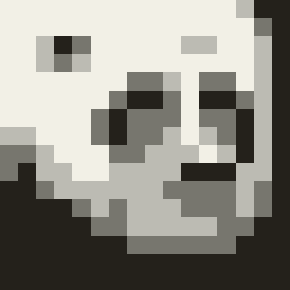

16×16，6色

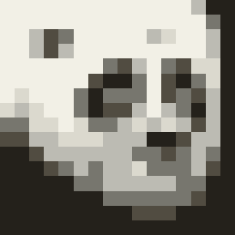

| 编号 | 代表色 | RGB | 码字 |
| --- | --- | --- | --- |
| 0 |  | (36, 33, 27) | — |
| 1 |  | (119, 118, 110) | — |
| 2 |  | (188, 187, 179) | — |
| 3 |  | (242, 240, 230) | — |
| 4 |  | (81, 76, 65) | — |
| 5 |  | (219, 217, 206) | — |

**D4局部证据｜同一个样本的选择改变了吗？（27页）**

| 可选颜色数 | 同一样本平均RGB | 代表色编号 | 代表色RGB |
| --- | --- | --- | --- |
| 4 | (78.25, 73.31, 68.4) | 0 | (36, 33, 27) |
| 6 | (78.25, 73.31, 68.4) | 4 | (81, 76, 65) |

**D5｜颜色数、位深度怎样联系？（Q10–Q13，30–41页）**

| 需区分颜色数 | 最少bit | 码字容量 |
| --- | --- | --- |
| 2 | 1 | 2 |
| 4 | 2 | 4 |
| 6 | 3 | 8 |
| 16 | 4 | 16 |
| 256 | 8 | 256 |

**D6｜三幅图的像素码字占多少？（Q11–Q12，34–37页）**

| 横×纵 | 可选颜色 | 每像素bit | 总bit | 理想B |
| --- | --- | --- | --- | --- |
| 8×8 | 4 | 2 | 128 | 16 |
| 16×16 | 4 | 2 | 512 | 64 |
| 16×16 | 6 | 3 | 768 | 96 |

**D7｜R=138怎样写成8位二进制？（Q14–Q15，44–50页）**

| 通道 | 十进制 | 8位二进制 |
| --- | --- | --- |
| R | 138 | 10001010 |
| G | 179 | 10110011 |
| B | 111 | 01101111 |

| 位权 | R通道该位 | 贡献 |
| --- | --- | --- |
| 128 | 1 | 128 |
| 64 | 0 | 0 |
| 32 | 0 | 0 |
| 16 | 0 | 0 |
| 8 | 1 | 8 |
| 4 | 0 | 0 |
| 2 | 1 | 2 |
| 1 | 0 | 0 |

**D8｜500×333的24位图像有多大？（Q16，51–53页）**

| 像素数 | 总bit | 理想像素B | KiB（1024B） |
| --- | --- | --- | --- |
| 166500 | 3996000 | 499500 | 487.79 |

**D8补充证据｜真实PNG文件大小等于公式吗？（53页）**

| 对象 | 结果 |
| --- | --- |
| 理想像素码字（B） | 64 |
| 这次PNG完整文件（B） | 164 |
| PNG索引位数 | 2 |
| 读回颜色编号完全相同 | 是 |
| 读回RGB像素完全相同 | 是 |

**D9｜放大显示能产生新细节吗？（Q17，54–55页）**

同一份8×8数据

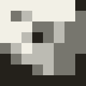

只扩大显示尺寸

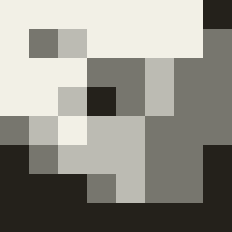

**D10｜只有这些码字，能唯一画出图像吗？（Q18，58–60页）**

```
11 11 01 00 00 01 11 00
```

| 编号 | 代表色 | RGB | 码字 |
| --- | --- | --- | --- |
| 0 |  | (36, 33, 27) | 00 |
| 1 |  | (119, 118, 110) | 01 |
| 2 |  | (188, 187, 179) | 10 |
| 3 |  | (242, 240, 230) | 11 |

**D10证据｜约定每行宽度后，再读回验证**

横4 × 纵2

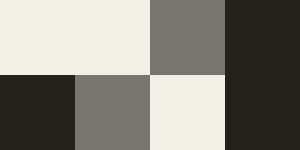

| 行 | 颜色编号（从左到右） |
| --- | --- |
| 1 | 3 3 1 0 |
| 2 | 0 1 3 0 |

```
按行读回： 11 11 01 00 00 01 11 00
与输入码字相同： True
```

**D11｜连续量与有限位置有什么不同？（Q19–Q21，65–76页；85页附录）**

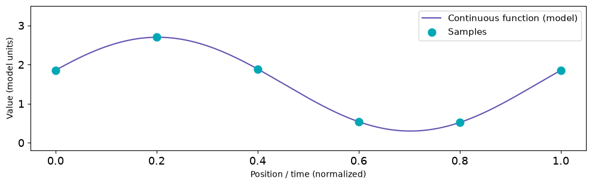

**D11证据｜位置不变，数值限制为四级**

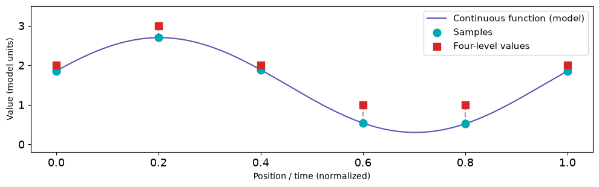

| 位置 | 样本值（近似） | 量化级 | 2位码 |
| --- | --- | --- | --- |
| 0 | 1.85 | 2 | 10 |
| 0.2 | 2.7 | 3 | 11 |
| 0.4 | 1.89 | 2 | 10 |
| 0.6 | 0.54 | 1 | 01 |
| 0.8 | 0.52 | 1 | 01 |
| 1 | 1.85 | 2 | 10 |

**D12｜32B预算下，哪些方案可行？（Q21-budget，78–79页）**

| 方案 | 容量 | 像素B | 容量足够 | 数据量达标 | 两项都满足 |
| --- | --- | --- | --- | --- | --- |
| A | 4 | 64 | 是 | 否 | 否 |
| B | 4 | 32 | 是 | 是 | 是 |
| C | 2 | 32 | 否 | 是 | 否 |
| D | 4 | 16 | 是 | 是 | 是 |

**E1｜独立退出题，先交答再核对（80–82页）**

| 核对项目 | 反馈 |
| --- | --- |
| 已提交 | 否 |
| 提示 | 先独立交答；收齐后再把submitted改为True核对。 |